# PreProcessing ASVs with Phyloseq

Kailyn Hanke

2025-03-30

In this analysis document I will be combining my data into a phyloseq object and removing any contaminating ASVs. I will be using data from a 2020 paper titled: “Tracking the Dairy Microbiota from Farm Bulk Tank to Skimmed Milk Powder” (@mchughTrackingDairyMicrobiota2020). By analyzing this data I want to answer the broad research question: How does microbial diversity change throughout the skim milk powder manufacturing process?

# Goals

First, we will use the [phyloseq package](https://joey711.github.io/phyloseq/) to combine all of our data objects that we exported from the DADA2 workflow (`asv_table`, `tax_table`, and metadata) and incorporate them into a single [specialized S4 R Data object](https://adv-r.hadley.nz/s4.html), known as a phyloseq object. Then, we will remove any potential contaminants and evaluate the accuracy of our sequencing run. Finally, we will write our our single `raw_preprocessed_physeq` phyloseq data object.

## Specific Steps:

1. Load in data that we’ve generated in `analysis/02_AssignASVs.Rmd` and fix all of the names to match each other. *The names must match for us to incorporate them into the S4 phyloseq object*:
   1. `asv_table`: ASVs (rows) x Samples (columns)
   2. `tax_table`: ASV (rows) x Taxonomy (columns)
   3. `metadata`: Samples (rows) x All our data (*e.g. pH, Temp, treatment group, etc*; columns)
2. Combine the data into a phyloseq object.
3. Remove any contaminating ASVs that are **chloroplasts**.
4. Remove ASVs that are **mitochondria**.
5. Evaluate any ASVs from the **negative controls**. Then, remove negative controls.
6. Evaluate the mock community or **positive control** to learn the accuracy of sequencing.
7. Check for **reverse complements**.
8. Check the **sequencing depth** of samples. Remove samples that obviously have too few reads.
9. Write a `raw_preprocessed_physeq` to be used in the next step of our workflow.

## Output

1. A **pre-processed S4 phyloseq object**: `raw_preprocessed_physeq.RData`.

# Set Environment

### Set the seed

```r
# Any number can be chosen
set.seed(111111)
```

## Load Packages

```r
#install.packages("BiocManager")
#BiocManager::install("Biostrings")

# NOTE, you will need to install the following 2 packages to
# re-create the negative control plots below!
#install.packages("ggpubr")
#install.packages("rstatix")

# Load packages with pacman
# Be sure that you load dada2 & Patchwork, which we didn't do in class on March 12th
pacman::p_load(devtools, phyloseq, dada2, patchwork, Biostrings, tidyverse,
               # Note to add ggpubr & rstatix!!
               ggpubr, rstatix, install = FALSE)
```

## Timing of this script

Let’s record how long this file took to run on the class server, which we will record at the end of the script.

```r
# What time did we start running this script?
start_time <- Sys.time()
```

Here, we will load in our **metadata** files, which include:

```r
# load in metadata
metadata_df <-
  read_csv("data/metadata_amplicon_project.csv") %>%
  # Fix Column Name
  dplyr::rename("sample_names" = "Run") %>%
  # Fix additional column name (so can plot metadata)
  dplyr::rename("environment_material" = "environment_(material)") %>%
  dplyr::rename("environment_feature" = "environment_(feature)") %>%
  dplyr::rename("environment_biome" = "environment_(biome)") %>%
  # Add sample names also as a column
  mutate(names = sample_names)
# Inspect
head(metadata_df)
```

```
## # A tibble: 6 × 51
##   sample_names `Assay Type` AvgSpotLen     Bases BioProject BioSample      Bytes
##   <chr>        <chr>             <dbl>     <dbl> <chr>      <chr>          <dbl>
## 1 ERR3141389   AMPLICON            502 112309448 PRJEB31110 SAMEA5320049  6.64e7
## 2 ERR3141394   AMPLICON            502 242619612 PRJEB31110 SAMEA5320054  1.50e8
## 3 ERR3141402   AMPLICON            502  60541200 PRJEB31110 SAMEA5320062  3.72e7
## 4 ERR3141408   AMPLICON            502  65790614 PRJEB31110 SAMEA5320068  3.95e7
## 5 ERR3141411   AMPLICON            502 112823496 PRJEB31110 SAMEA5320071  6.65e7
## 6 ERR3141412   AMPLICON            502  95800174 PRJEB31110 SAMEA5320072  6.05e7
## # ℹ 44 more variables: `Center Name` <chr>, Collection_Date <chr>,
## #   Consent <chr>, `DATASTORE filetype` <chr>, `DATASTORE provider` <chr>,
## #   `DATASTORE region` <chr>, `ENA-FIRST-PUBLIC (run)` <chr>,
## #   `ENA-FIRST-PUBLIC` <dttm>, `ENA-LAST-UPDATE (run)` <chr>,
## #   `ENA-LAST-UPDATE` <dttm>, environment_biome <chr>,
## #   environment_feature <chr>, environment_material <chr>, Experiment <chr>,
## #   external_id <chr>, geo_loc_name_country <chr>, …
```

```r
dim(metadata_df)
```

```
## [1] 208  51
```

```r
# include dada2 output
load("data/01_DADA2/track_read_counts.RData")

# Take a look
glimpse(track_counts_df)
```

```
## Rows: 208
## Columns: 6
## $ sample_names <chr> "ERR3141386_1_filtered.fastq.gz", "ERR3141387_1_filtered.…
## $ denoisedF    <dbl> 112784, 101592, 269420, 146380, 154699, 89399, 128138, 14…
## $ denoisedR    <dbl> 113612, 102152, 269937, 146413, 155175, 89588, 128320, 14…
## $ merged       <dbl> 99063, 85110, 249718, 137732, 142389, 81453, 119689, 1263…
## $ nochim       <dbl> 60993, 47011, 170431, 109452, 52547, 63605, 92251, 82302,…
## $ num_ASVs     <dbl> 794, 961, 841, 459, 626, 415, 502, 957, 1834, 1218, 1197,…
```

```r
dim(track_counts_df)
```

```
## [1] 208   6
```

```r
# Check filenames
head(track_counts_df$sample_names)
```

```
## [1] "ERR3141386_1_filtered.fastq.gz" "ERR3141387_1_filtered.fastq.gz"
## [3] "ERR3141388_1_filtered.fastq.gz" "ERR3141389_1_filtered.fastq.gz"
## [5] "ERR3141390_1_filtered.fastq.gz" "ERR3141391_1_filtered.fastq.gz"
```

```r
# Fix sample names in track_reads
track_counts_df$sample_names <- sapply(strsplit(track_counts_df$sample_names, "_"), `[`, 1)

# Intuition check
head(track_counts_df$sample_names)
```

```
## [1] "ERR3141386" "ERR3141387" "ERR3141388" "ERR3141389" "ERR3141390"
## [6] "ERR3141391"
```

```r
# What's different?
setdiff(track_counts_df$sample_names, metadata_df$sample_names)
```

```
## character(0)
```

```r
# Let's do a filtering join with left_join
metadata_final_df <-
  metadata_df %>%
  left_join(., track_counts_df, by = "sample_names") %>%
  # sample names to the rownames to merge into phyloseq
  column_to_rownames(var = "sample_names")

# Check
dim(metadata_final_df)
```

```
## [1] 208  55
```

### 1b. ASV Table

Now, let’s load in the ASV count table that we created within DADA2 in `analysis/02_AssignASVs.Rmd`.

```r
asv_df <-
  read.delim(file = "data/01_DADA2/ASV_table.tsv", sep = "\t",
           # add the column names and row names
           header = TRUE, row.names = 1)

# Final inspection
head(colnames(asv_df))
```

```
## [1] "ERR3141386" "ERR3141387" "ERR3141388" "ERR3141389" "ERR3141390"
## [6] "ERR3141391"
```

```r
asv_df[1:3, 1:3]
```

```
##          ERR3141386 ERR3141387 ERR3141388
## ASV_0001          7          0         15
## ASV_0002       1162         94      24197
## ASV_0003       1705        146      16118
```

### 1c. Taxonomy Table

And, let’s also load the taxonomy table that we created in `analysis/02_AssignASVs.Rmd`.

```r
tax_df <-
  read.delim("data/01_DADA2/ASV_taxonomy.tsv", sep = "\t",
           header = TRUE, row.names = 1)

# Inspect
dim(tax_df)
```

```
## [1] 75334     9
```

```r
dim(asv_df)
```

```
## [1] 75334   208
```

```r
# Add check
stopifnot(rownames(asv_df) == rownames(tax_df))
```

# 2. Handoff to phyloseq

This is where we will combine our metadata, asv count table, and taxonomy table into a single data S4 data object in R, which we will call `raw_physeq` for now.

```r
raw_physeq <-
  phyloseq(otu_table(asv_df, taxa_are_rows = TRUE),
         sample_data(metadata_final_df),
         tax_table(as.matrix(tax_df)))

# Check out
raw_physeq
```

```
## phyloseq-class experiment-level object
## otu_table()   OTU Table:         [ 75334 taxa and 208 samples ]
## sample_data() Sample Data:       [ 208 samples by 55 sample variables ]
## tax_table()   Taxonomy Table:    [ 75334 taxa by 9 taxonomic ranks ]
```

```r
# save
save(raw_physeq, file = "data/03_PreProcessing/raw_physeq.RData")
```

## 3. Remove chloroplasts

```r
noChloros_physeq <-
  raw_physeq %>%
  subset_taxa(Order != "Chloroplast" | is.na(Order))

# How many ASVs were chloroplasts?
numChloros_ASVs <- ntaxa(raw_physeq) - ntaxa(noChloros_physeq)
```

There were 36 ASVs that were chloroplasts.

## 4. Remove Mitochondria

```r
noChlorosMitos_physeq <-
  noChloros_physeq %>%
  subset_taxa(Family != "Mitochondria" | is.na(Family))

# How many ASVs were mitochondria?
numMitos_ASVs <- ntaxa(noChloros_physeq) - ntaxa(noChlorosMitos_physeq)
```

There were 450 ASVs that were mitochondria in the data set.

Interpretation #1: How many chloroplast and/or mitochondrial ASVs in your dataset? Does this seem reasonable?

There were 36 chloroplast ASVs and 450 mitochondrial ASVs identified in my dataset. I was surprised that only 36 chloroplast ASVs were identified due to the large number of samples and how deeply sequenced this dataset is. Even though 450 mitochondrial ASVs seems like quite a large number, I think this is reasonable, given that in my dataset there are over 75 000 ASVs identified.

# Evaluate and remove the control samples

Now, let’s take a look at the negative controls and then make a decision about whether or not to remove the ASVs that we found in our controls

1. Negative controls
2. ASVs found within the negative controls and their distribution in the samples.
3. Evaluate the mock community

## 5. Negative Controls

INTERPRETATION #2: Did your dataset have any negative controls? If so, how many ASVs did you remove? Does that seem reasonable to you?

No, my dataset did not have any negative controls! Because of this I did not remove any ASVs. Like Mar stated, negative controls are not optional, so it doesn’t seem very reasonable to me that there were no negative controls in this dataset.

## 6. Positive Controls

INTERPRETATION #3: Did your dataset have a mock community? If so, what can you say about the accuracy of your sequencing run?

My dataset did not have a mock community, so I was not able to make any conclusions about the accuracy of my sequencing run.

# 7. Reverse Complements

```r
# Pull out Taxa Table
tax_table <-
  noChlorosMitos_physeq %>%
  tax_table() %>%
  data.frame()

# Grab ASV Sequences and Names
asv_names <- tax_table$ASV
asv_seqs <- tax_table$ASVseqs

# Create empty comparison matrix
asv_rev_comp <- matrix(nrow=length(asv_seqs), ncol = length(asv_seqs))

# Fix the names in the rows and columns
rownames(asv_rev_comp) <- asv_names
colnames(asv_rev_comp) <- asv_names

# Convert sequences to Biostrings
asv_dna <- DNAStringSet(asv_seqs)

# Inspect
head(asv_dna)
```

```
## DNAStringSet object of length 6:
##     width seq
## [1]   428 TAGGGAATCTTCCGCAATGGGCGAAAGCCTGACG...GACGCTGAGGCGCGAAAGCGTGGGGAGCAAACA
## [2]   428 TGGGGAATATTGGACAATGGGGGGAACCCTGATC...GACACTGAGGTACGAAAGCATGGGGAGCAAACA
## [3]   427 TAGGGAATCTTCGGCAATGGACGAAAGTCTGACC...GACACTGAGGCTCGAAAGCGTGGGGAGCAAACA
## [4]   428 TGGGGAATATTGGACAATGGGGGGAACCCTGATC...GACACTGAGGTACGAAAGCATGGGGAGCAAACA
## [5]   415 TTAGGAATCTTCCGCAATGGGCGCAAGCCTGACG...GACGCTGAGGCGCGAAAGCGTGGGGAGCAAACC
## [6]   427 TGGGGAATATTGGACAATGGGCGAAAGCCTGATC...GACACTGAGGTGCGAAAGCGTGGGGAGCAAACA
```

```r
# Construct reverse complement
asv_rev_dna <- reverseComplement(asv_dna)

# Now loop through every asv sequence to check
for(i in 1:length(asv_seqs)){ # For each asv sequence...
  match_vec <- asv_dna[i] == asv_rev_dna # Compare it to the reverse complement of every other sequence...
  asv_rev_comp[,i] <- match_vec # Write that logical vector as a new column
}

# Find how many TRUEs (matches) we have, divide by 2 because each pair occurs twice
cat("For", sum(asv_rev_comp) / 2,"ASVs, the reverse complement will need to be removed")
```

```
## For 0 ASVs, the reverse complement will need to be removed
```

INTERPRETATION #4: Do you have any reverse complements in your dataset?

No I do not have any reverse complements that need to be removed.

# 8. Sequencing Depth

Let’s take a look!

```r
# The current data objec
noChlorosMitos_physeq
```

```
## phyloseq-class experiment-level object
## otu_table()   OTU Table:         [ 74848 taxa and 208 samples ]
## sample_data() Sample Data:       [ 208 samples by 55 sample variables ]
## tax_table()   Taxonomy Table:    [ 74848 taxa by 9 taxonomic ranks ]
```

```r
# What is the library size/sequencing depth for each sample?
seqSums_df <-
  noChlorosMitos_physeq %>%
  otu_table() %>%
  # Sum each sample column
  colSums() %>%
  data.frame() %>%
  rownames_to_column(var = "names") %>%
  left_join(., metadata_final_df, by = "names")

# Rename second column
colnames(seqSums_df)[2] <- "TotalSeqs"

# check
dim(seqSums_df)
```

```
## [1] 208  56
```

```r
head(seqSums_df)
```

```
##        names TotalSeqs Assay Type AvgSpotLen     Bases BioProject    BioSample
## 1 ERR3141386     60940   AMPLICON        502  99546098 PRJEB31110 SAMEA5320046
## 2 ERR3141387     47011   AMPLICON        502  90531684 PRJEB31110 SAMEA5320047
## 3 ERR3141388    170406   AMPLICON        502 211145718 PRJEB31110 SAMEA5320048
## 4 ERR3141389    109444   AMPLICON        502 112309448 PRJEB31110 SAMEA5320049
## 5 ERR3141390     52196   AMPLICON        502 127532598 PRJEB31110 SAMEA5320050
## 6 ERR3141391     63605   AMPLICON        502  68124412 PRJEB31110 SAMEA5320051
##       Bytes                  Center Name Collection_Date Consent
## 1  62822225 TEAGASC FOOD RESEARCH CENTRE       5/18/2016  public
## 2  54410542 TEAGASC FOOD RESEARCH CENTRE       5/18/2016  public
## 3 129707696 TEAGASC FOOD RESEARCH CENTRE       5/18/2016  public
## 4  66426848 TEAGASC FOOD RESEARCH CENTRE       5/18/2016  public
## 5  79143820 TEAGASC FOOD RESEARCH CENTRE       5/18/2016  public
## 6  40072504 TEAGASC FOOD RESEARCH CENTRE       5/18/2016  public
##   DATASTORE filetype DATASTORE provider
```

[output cut: 97 more lines]

```r
# Show the depth of samples
seqSums_df %>%
  dplyr::select(names, TotalSeqs) %>%
  arrange(TotalSeqs) %>%
  head()
```

```
##        names TotalSeqs
## 1 ERR3143462       533
## 2 ERR3143466       648
## 3 ERR3143470       854
## 4 ERR3143474      1063
## 5 ERR3143460      1071
## 6 ERR3143465      1358
```

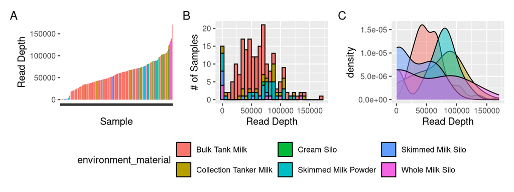

```r
# plot it as a bar plot
numSeq_bar_plot <-
  seqSums_df %>%
  ggplot(aes(x=reorder(names, TotalSeqs), y = TotalSeqs,
             fill = environment_material)) +
  geom_bar(stat = "identity") +
  theme(axis.text.x = element_blank()) +
  labs(y = "Read Depth", x = "Sample") +
  theme(legend.position = "none")

# histogram
numSeq_hist_plot <-
  seqSums_df %>%
  ggplot(aes(x= TotalSeqs, fill = environment_material)) +
  geom_histogram(color = "black") +
  labs(y = "# of Samples", x = "Read Depth") +
  theme(legend.position = "bottom")

# Density plot
numSeq_density_plot <-
  seqSums_df %>%
  ggplot(aes(TotalSeqs, fill = environment_material)) +
  geom_density(alpha = 0.5) +
  labs(x = "Read Depth") +
  theme(legend.position = "none")

# Put it all together
numSeq_bar_plot + numSeq_hist_plot + numSeq_density_plot +
  plot_annotation(tag_levels = "A")
```

INTERPRETATION #5: What can you conclude about your sequencing depths? What are your sample distributions? Do you have “enough” reads? Are there any samples that should be removed at this step?

From these plots I can conclude that the majority of my samples have a read depth between (approximately) 45000 and 100000 which is great. Something else I immediately noticed from these plots is that it appears that 15 samples have a read depth that is very low. In the code below I checked to see what the minimum sequencing depth is, and I discovered it was 533. I then made a dataframe to look at which samples had low sequencing depth. I decided to remove all the samples with a read depth below 1500, like Mar did in their example. To do this, I removed seven samples: ERR3143462, ERR3143466, ERR3143470, ERR3143474, ERR3143460, ERR3143465, ERR3143464. After doing this processing the minimum read depth for a sample is 1524. Will confirm with Mar/Sophia if this is an appropriate cutoff for my dataset.

```r
# What's the min seq depth?

min(sample_sums(noChlorosMitos_physeq))
```

```
## [1] 533
```

```r
#Making a dataframe to inspect further.
sample_depths <- data.frame(
  Sample = sample_names(noChlorosMitos_physeq),
  Depth = sample_sums(noChlorosMitos_physeq)
)

# Sort it from lowest to highest
sample_depths_sorted <- sample_depths[order(sample_depths$Depth), ]

head(sample_depths_sorted, n=20)  # View lowest-depth samples
```

```
##                Sample Depth
## ERR3143462 ERR3143462   533
## ERR3143466 ERR3143466   648
## ERR3143470 ERR3143470   854
## ERR3143474 ERR3143474  1063
## ERR3143460 ERR3143460  1071
## ERR3143465 ERR3143465  1358
## ERR3143464 ERR3143464  1414
## ERR3143472 ERR3143472  1524
## ERR3143463 ERR3143463  1620
## ERR3143468 ERR3143468  1754
## ERR3143467 ERR3143467  1781
## ERR3143461 ERR3143461  1804
## ERR3143469 ERR3143469  1884
## ERR3143475 ERR3143475  2536
## ERR3143471 ERR3143471  2773
## ERR3143473 ERR3143473  3613
## ERR3141454 ERR3141454  4430
## ERR3141501 ERR3141501  9143
## ERR3141434 ERR3141434  9926
## ERR3141489 ERR3141489 17924
```

```r
# Remove the seven samples
raw_preprocessed_physeq <-
  noChlorosMitos_physeq %>%
  subset_samples(!(names %in% c("ERR3143462", "ERR3143466", "ERR3143470",
                                "ERR3143474", "ERR3143460", "ERR3143465", "ERR3143464")))

min(sample_sums(raw_preprocessed_physeq))
```

```
## [1] 1524
```

# 9. Save Output

## Raw Preprocessed Phyloseq Object

Finally, let’s save our phyloseq object, which we will use for the next step!

```r
save(raw_preprocessed_physeq, file = "data/03_PreProcessing/raw_preprocessed_physeq.RData")
```

# Final Thoughts

In this document I combined my data into a phyloseq object and removed any contaminating ASVs that were chloroplasts or mitochondria. I evaluated (or tried to evaluate since there were no controls) for controls. I also checked for reverse complements and the sequencing depth.

# Final info for Reproducibility

## Check Render Time

```r
# Take the time now that we are at the end of the script
end_time <- Sys.time()
end_time
```

```
## [1] "2025-05-02 16:48:33 EDT"
```

```r
# Echo the elapsed time
elapsed_time <- round((end_time - start_time), 3)
elapsed_time
```

```
## Time difference of 5.839 mins
```